# Screening and Cleaning Recent Probes Task

3.1 Are the bad subjects elevated on certain personality traits? If they are more trait impulsive, if they’re on the borderline there may be an argument for keeping them.

```r
if(create_plots){
  # png("Figures/bad_subject_SNAP_histograms.png")#, width = 11, height = 8)
  pdf(paste0(figuredir,"/bad_subject_SNAP_histograms_rp.pdf"), width = 11, height = 8)
  for(s in names(SNAPz)[-1]){
    x <- SNAPz %>% filter(Subject %in% badsubs) %>% na.omit()%>% select(s, "Subject")#%>% mutate(clr = letters[1:nrow(.)]) #%>% as.matrix() # 38 doesnt have SNAP
    x$Subject <- as.factor(x$Subject)
    x[,s] <- jitter(x[,s])
    p <- ggplot(SNAPz, aes_string(x = s)) + geom_histogram() + geom_vline(data = x, aes_string(xintercept = s, color = "Subject"), linetype = "dotted", size = 1)
    plot(p)
  }
  dev.off()
}
```

Seems to be a bit more skewed towards pathology in the probes data. E.g. subject 100 is consistently elevated on externalizing measures, but what are we gonna do about it? Unfortunately, these are different folks than we dropped for flanker.

```r
rp_acc_trim <- rp %>% filter(!Subject %in% badsubs) %>% arrange(Subject, Trial)
length(unique(rp_acc_trim$Subject))
```

```
## [1] 107
```

4. Identify unbelievably fast RTs < 100ms. Recode both RT and accuracy to NA. Consider different options for long outliers (e.g. censoring vs winsorizing)

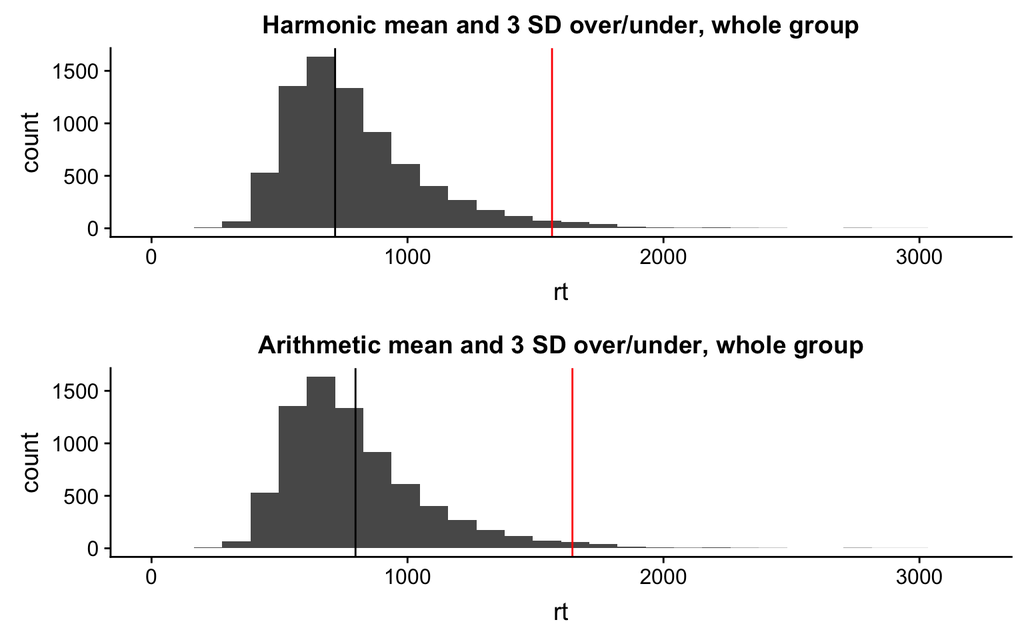

```r
# str(rp_acc_trim)
detach("package:plyr", unload=TRUE);
rp_acc_trim <- rp_acc_trim %>% rename(`rt` = `ProbeDisplay_RT`)
rp_acc_trim$Condition <- recode(rp_acc_trim$Condition, Y = "positive",
       Nfam0 = "n_unfam",
       Nfam1= "n_fam",
       Nfam2 = "n_hfam",
       Nfam1RI = "n_rc")

# alot of this is vestigial from the flanker code, which was way more complicated than it needs to be

rp_acc_trim <- rp_acc_trim %>% mutate(group_Amean_rt = mean(rt, na.rm = TRUE),
                                            group_Hmean_rt = harmonic.mean(rt, na.rm = TRUE),
                                            group_SD_rt = sd(rt, na.rm = TRUE)) %>% mutate(group_SD3Amean_rt_high = group_Amean_rt + 3*group_SD_rt,
                                                                                            group_SD3Amean_rt_low = group_Amean_rt - 3*group_SD_rt,
                                                                                            group_SD3AHmean_rt_high = group_Hmean_rt + 3*group_SD_rt,
                                                                                            group_SD3AHmean_rt_low = group_Hmean_rt - 3*group_SD_rt) %>%
  group_by(Condition) %>% mutate(group_conAmean_rt = mean(rt, na.rm = TRUE),
                                            group_conHmean_rt = harmonic.mean(rt, na.rm = TRUE),
                                            group_conSD_rt = sd(rt, na.rm = TRUE)) %>% mutate(group_conSD3Amean_rt_high = group_conAmean_rt + 3*group_conSD_rt,
                                                                                            group_conSD3Amean_rt_low = group_conAmean_rt - 3*group_conSD_rt,
                                                                                            group_conSD3AHmean_rt_high = group_conHmean_rt + 3*group_conSD_rt,
                                                                                            group_conSD3AHmean_rt_low = group_conHmean_rt - 3*group_conSD_rt) %>%  ungroup() %>%
  group_by(Subject) %>% mutate(Amean_rt = mean(rt, na.rm = TRUE),
                               Hmean_rt = harmonic.mean(rt, na.rm = TRUE),
                               SD_rt = sd(rt, na.rm = TRUE)) %>% mutate(SD3Amean_rt_high = Amean_rt + 3*SD_rt,
                                                                         SD3Amean_rt_low = Amean_rt - 3*SD_rt,
                                                                         SD3AHmean_rt_high = Hmean_rt + 3*SD_rt,
                                                                         SD3AHmean_rt_low = Hmean_rt - 3*SD_rt) %>%
  group_by(Subject, Condition) %>% mutate(con_Amean_rt = mean(rt, na.rm = TRUE),
                                            con_Hmean_rt = harmonic.mean(rt, na.rm = TRUE),
                                            con_SD_rt = sd(rt, na.rm = TRUE)) %>% mutate(con_SD3Amean_rt_high = con_Amean_rt + 3*con_SD_rt,
                                                                                          con_SD3Amean_rt_low = con_Amean_rt - 3*con_SD_rt,
                                                                                          con_SD3AHmean_rt_high = con_Hmean_rt + 3*con_SD_rt,
                                                                                          con_SD3AHmean_rt_low = con_Hmean_rt - 3*con_SD_rt)

# if(create_plots){
  # pdf(paste0(figuredir,"subject_rt_dists_raw_rp.pdf"), width = 11, height = 8)

  #plot group first
  x <- ggplot(rp_acc_trim, aes(x = rt)) + geom_histogram() +
    geom_vline(xintercept = unique(rp_acc_trim$group_Hmean_rt)) +
    geom_vline(xintercept = unique(rp_acc_trim$group_SD3AHmean_rt_low), color = "red") +
    geom_vline(xintercept = unique(rp_acc_trim$group_SD3AHmean_rt_high), color = "red") + xlim(0,3200) +
    labs(title = "Harmonic mean and 3 SD over/under, whole group")

  y <- ggplot(rp_acc_trim, aes(x = rt)) + geom_histogram() +
    geom_vline(xintercept = unique(rp_acc_trim$group_Amean_rt)) +
    geom_vline(xintercept = unique(rp_acc_trim$group_SD3Amean_rt_low), color = "red") +
    geom_vline(xintercept = unique(rp_acc_trim$group_SD3Amean_rt_high), color = "red") + xlim(0,3200) +
    labs(title = "Arithmetic mean and 3 SD over/under, whole group")

  cowplot::plot_grid(x,y, ncol = 1)
```

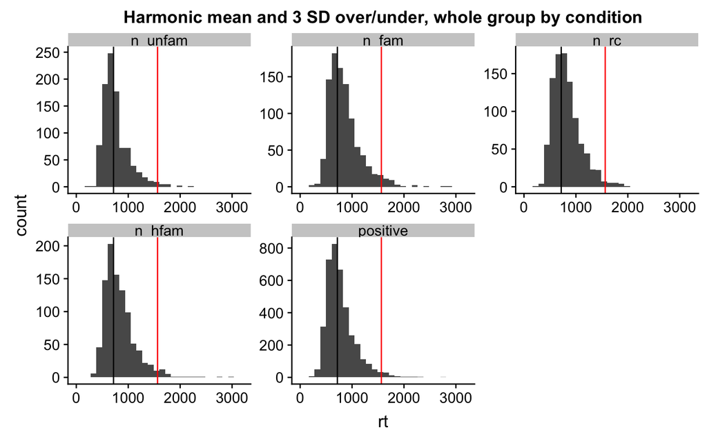

```r
  x <- ggplot(rp_acc_trim, aes(x = rt)) + geom_histogram() +
    geom_vline(xintercept = unique(rp_acc_trim$group_Hmean_rt)) +
    geom_vline(xintercept = unique(rp_acc_trim$group_SD3AHmean_rt_low), color = "red") +
    geom_vline(xintercept = unique(rp_acc_trim$group_SD3AHmean_rt_high), color = "red") + xlim(0,3200) +
    labs(title = "Harmonic mean and 3 SD over/under, whole group by condition") + facet_wrap(~Condition, scales = "free")
  plot(x)
```

```r
 mean_sd_condition <-  rp_acc_trim %>% group_by(Condition) %>% summarise(harmonic_mean = harmonic.mean(rt, na.rm = TRUE), sd = sd(rt, na.rm = TRUE))


 mean_ci_conditions <- summarySEwithin(data = rp_acc_trim, measurevar = "rt", withinvars = "Condition", idvar = "Subject", na.rm = TRUE)
 detach("package:plyr", unload=TRUE); detach("package:dplyr", unload=TRUE); library(dplyr); library(plyr)
```

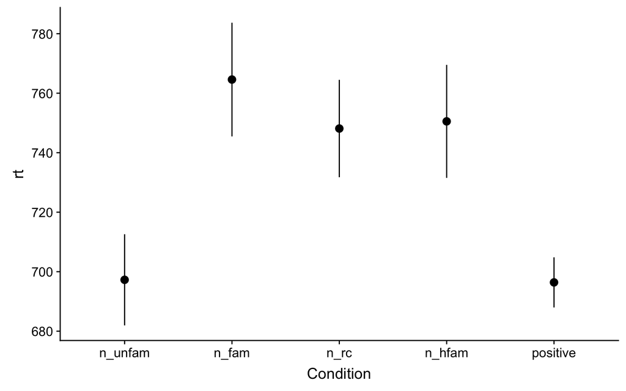

```r
 point_plot <- ggplot(mean_ci_conditions, aes(x = Condition, y = rt, group = 1)) +
   geom_point(shape = 21, size = 3, fill = "black") +
   geom_errorbar(width = 0, aes(ymin = rt-ci, ymax=rt+ci))

 plot(point_plot)
```

```r
range(rp_acc_trim$rt,na.rm = TRUE) # my hunch is that NA trials are timeouts
```

```
## [1]  170 3014
```

```r
quantile(rp_acc_trim$rt, na.rm = TRUE, probs = c(0,.05,.1, .9, .95,.99,1))
```

```
##      0%      5%     10%     90%     95%     99%    100%
##  170.00  464.00  514.00 1163.00 1352.00 1723.15 3014.00
```

```r
perc.rank <- function(x, xo)  length(x[x <= xo])/length(x)*100

perc.rank(rp_acc_trim$rt, 350); #length(rp_acc_trim$Subject) * perc.rank(rp_acc_trim$rt, 150)/100
```

```
## [1] 1.090343
```

```r
perc.rank(rp_acc_trim$rt, 400); #length(rp_acc_trim$Subject) * perc.rank(rp_acc_trim$rt, 250)/100
```

```
## [1] 1.869159
```

```r
length(which(rp_acc_trim$rt <= 350));length(which(rp_acc_trim$rt <= 350))/length(rp_acc_trim$rt)
```

```
## [1] 38
```

```
## [1] 0.004932503
```

```r
length(which(rp_acc_trim$rt <= 400));length(which(rp_acc_trim$rt <= 400))/length(rp_acc_trim$rt)
```

```
## [1] 98
```

```
## [1] 0.01272066
```

I think a principled manner of dealing with outliers in this data is to exclude (set to NA) trials that are below 350 ms. I tried 400 ms and down the line one subject gets hammered bc many of their RTs are within the 350-400 range and still got a number of them correct.

```r
# perc.rank(rp_acc_trim$rt, 700)
# table(rp_acc_trim$group_SD3AHmean_rt_high)
table(rp_acc_trim$group_conSD3AHmean_rt_high)
```

```
##
## 1471.98054389473 1523.88773446354 1554.95941687725 1657.01650798141
##              963             3852              963              963
## 1694.34261129052
##              963
```

```r
# length(which(rp_acc_trim$rt >= rp_acc_trim$group_SD3AHmean_rt_high)); length(which(rp_acc_trim$rt >= rp_acc_trim$group_SD3AHmean_rt_high))/length(rp_acc_trim$Subject)
length(which(rp_acc_trim$rt >= rp_acc_trim$group_conSD3AHmean_rt_high)); length(which(rp_acc_trim$rt >= rp_acc_trim$group_conSD3AHmean_rt_high))/length(rp_acc_trim$Subject)
```

```
## [1] 166
```

```
## [1] 0.02154725
```

This seems sane theoretically, but is also data-driven. We will winsorize long rts based on group-level estimates for what value is 3SDs above the harmonic mean for each condition across subjects, estimated separately per condition.

```r
str(rp_acc_trim)
```

[output not shown]

[output cut: 94 more lines]

[output not shown]

```r
rp_cleaned <- rp_acc_trim
rp_cleaned$rt <- ifelse(rp_cleaned$rt <= 350, NA, rp_cleaned$rt) # drop short RTs
rp_cleaned$rt <- ifelse(rp_cleaned$rt >= rp_cleaned$group_conSD3AHmean_rt_high, rp_cleaned$group_conSD3AHmean_rt_high, rp_cleaned$rt) # winsorize long RTs by group-level congruent vs incongruent.
```

5. Compute and display (as table) summary statistics for RT by subject and block. May need to leverage harmonic mean (Ratcliff) or ex-Gaussian fitted statistics to get a sense of averages (given positive skew of RTs).

```r
summaries_rt <- rp_cleaned %>% group_by(Subject, Condition) %>% dplyr::summarise(sd = sd(rt, na.rm = TRUE),
                                                                       hmean = harmonic.mean(rt)) %>% arrange(-hmean)
head(summaries_rt)
```

```
## # A tibble: 6 x 4
## # Groups:   Subject [4]
##   Subject Condition    sd hmean
##     <dbl> <fct>     <dbl> <dbl>
## 1      64 n_fam      340. 1306.
## 2      72 n_fam      244. 1260.
## 3      64 n_hfam     239. 1199.
## 4       1 n_fam      317. 1174.
## 5      12 n_fam      255. 1147.
## 6      12 n_rc       287. 1139.
```

6. Screen for unlikely RT means between subjects, separating incongruent and congruent trials. For example, if the congruent sample average is ~250ms and one subject has a mean ~750ms, is this plausible? If not, discuss and potentially drop.

```r
condition_meansd <- rp_cleaned %>% group_by(Condition) %>% dplyr::summarise(g_mean = harmonic.mean(rt, na.rm = TRUE), g_sd = sd(rt, na.rm = TRUE), g_meansd = g_mean + 2*g_sd)
condition_meansd
```

```
## # A tibble: 5 x 4
##   Condition g_mean  g_sd g_meansd
##   <fct>      <dbl> <dbl>    <dbl>
## 1 n_unfam     699.  240.    1179.
## 2 n_fam       768.  286.    1340.
## 3 n_rc        752.  256.    1264.
## 4 n_hfam      752.  275.    1302.
## 5 positive    703.  256.    1214.
```

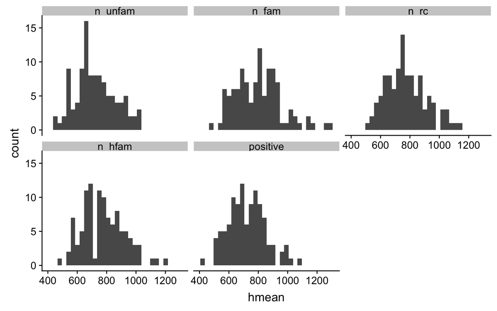

```r
p <- ggplot(summaries_rt, aes(x = hmean)) + geom_histogram()   + facet_wrap(~Condition) #+ geom_vline(xintercept = summaries_rt$g_mean, color = "red")
plot(p)
```

```r
summaries_rt <- summaries_rt %>% group_by(Subject) %>% mutate(sub_mean = mean(hmean)) %>% arrange(-hmean) %>% left_join(condition_meansd, by = "Condition")


#to look at this more formally just take those subjects that have combinations of stimulus type (cong vs incongr) and block type (most cong vs most incong)
summaries_rt %>% filter(hmean >= g_meansd)
```

```
## # A tibble: 0 x 8
## # Groups:   Subject [0]
## # … with 8 variables: Subject <dbl>, Condition <fct>, sd <dbl>,
## #   hmean <dbl>, sub_mean <dbl>, g_mean <dbl>, g_sd <dbl>, g_meansd <dbl>
```

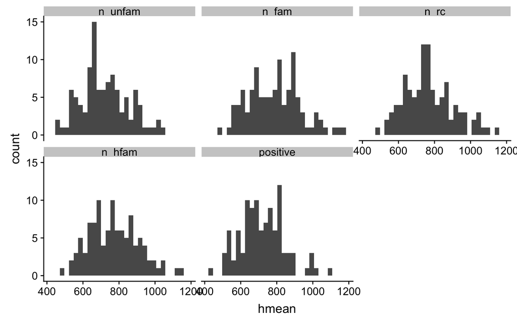

```r
p_trim <- ggplot(filter(summaries_rt, !Subject %in% c(64,72)), aes(x = hmean)) + geom_histogram()   + facet_wrap(~ Condition) #+ geom_vline(xintercept = summaries_rt$g_mean, color = "red")
plot(p_trim)
```

Honestly, I think they can stay in.

8. Check for subjects with a high number of NA trials. Could be due to RTs and accuracies that are not properly recorded (NA), or could be an unbelievably fast outlier. Consider removing subjects with a high number of NAs

```r
nas_persub <- rp_cleaned %>% group_by(Subject) %>% dplyr::summarise(na.counts_sub = length(which(is.na(rt)))) %>% arrange(-na.counts_sub)

table(nas_persub$na.counts_sub)
```

```
##
##  0  1  2  3  4  5  6  7 22
## 75 18  6  2  2  1  1  1  1
```

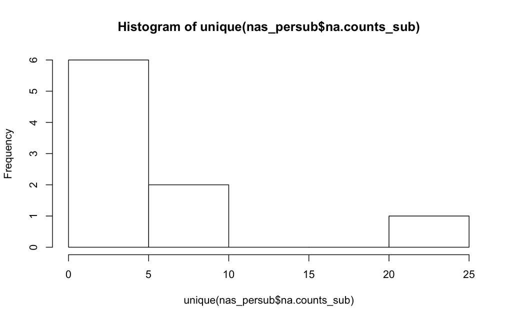

```r
hist(unique(nas_persub$na.counts_sub))
```

```r
head(nas_persub)
```

```
## # A tibble: 6 x 2
##   Subject na.counts_sub
##     <dbl>         <int>
## 1      36            22
## 2      48             7
## 3      92             6
## 4     106             5
## 5      87             4
## 6     112             4
```

```r
# 36 is pretty darn fast, are they getting them right?

rp_cleaned %>% filter(Subject == 36)
```

```
## # A tibble: 72 x 43
## # Groups:   Subject, Condition [5]
##    Subject Trial Condition CorrectAns DisplayBlock1 Letter Letter2 Letter3
##      <dbl> <dbl> <fct>     <fct>              <dbl> <fct>  <fct>   <fct>
##  1      36     9 n_unfam   f                      1 y      z       c
##  2      36    10 positive  j                      2 x      p       t
##  3      36    11 n_rc      f                      3 g      p       b
##  4      36    12 positive  j                      4 j      m       b
##  5      36    13 n_hfam    f                      5 j      q       r
##  6      36    14 positive  j                      6 x      w       q
##  7      36    15 n_fam     f                      7 p      w       k
##  8      36    16 positive  j                      8 g      p       n
##  9      36    17 positive  j                      9 f      q       d
## 10      36    18 n_rc      f                     10 z      w       d
## # … with 62 more rows, and 35 more variables: Letter4 <fct>,
## #   LetterDisplay_DurationError <dbl>, rt <dbl>, ProbeDisplay_ACC <dbl>,
## #   ProbeDisplay_CRESP <fct>, ProbeDisplay_RESP <fct>, ProbeLetter <fct>,
## #   group_Amean_rt <dbl>, group_Hmean_rt <dbl>, group_SD_rt <dbl>,
## #   group_SD3Amean_rt_high <dbl>, group_SD3Amean_rt_low <dbl>,
## #   group_SD3AHmean_rt_high <dbl>, group_SD3AHmean_rt_low <dbl>,
## #   group_conAmean_rt <dbl>, group_conHmean_rt <dbl>,
## #   group_conSD_rt <dbl>, group_conSD3Amean_rt_high <dbl>,
## #   group_conSD3Amean_rt_low <dbl>, group_conSD3AHmean_rt_high <dbl>,
## #   group_conSD3AHmean_rt_low <dbl>, Amean_rt <dbl>, Hmean_rt <dbl>,
## #   SD_rt <dbl>, SD3Amean_rt_high <dbl>, SD3Amean_rt_low <dbl>,
## #   SD3AHmean_rt_high <dbl>, SD3AHmean_rt_low <dbl>, con_Amean_rt <dbl>,
## #   con_Hmean_rt <dbl>, con_SD_rt <dbl>, con_SD3Amean_rt_high <dbl>,
## #   con_SD3Amean_rt_low <dbl>, con_SD3AHmean_rt_high <dbl>,
## #   con_SD3AHmean_rt_low <dbl>
```

yeah this guy needs to go. esp when looking at the last 10 or so trials.

```r
rp_cleaned <- rp_cleaned %>% filter(Subject != 36)
length(unique(rp_cleaned$Subject))
```

```
## [1] 106
```

9. Drop unnecessary variables before moving on to MLM

```r
str(rp_cleaned)
```

[output not shown]

[output cut: 93 more lines]

[output not shown]

```r
### N.B. for stimulus coding my assumption is that the Z that we calculate will bias subject towards answering positive or negative towards the probe.
head(rp_cleaned)
```

```
## # A tibble: 6 x 43
## # Groups:   Subject, Condition [4]
##   Subject Trial Condition CorrectAns DisplayBlock1 Letter Letter2 Letter3
##     <dbl> <dbl> <fct>     <fct>              <dbl> <fct>  <fct>   <fct>
## 1       1    11 n_unfam   j                      1 y      z       c
## 2       1    12 positive  f                      2 x      p       t
## 3       1    13 n_rc      j                      3 g      p       b
## 4       1    14 positive  f                      4 j      m       b
## 5       1    15 n_hfam    j                      5 j      q       r
## 6       1    16 positive  f                      6 x      w       q
## # … with 35 more variables: Letter4 <fct>,
## #   LetterDisplay_DurationError <dbl>, rt <dbl>, ProbeDisplay_ACC <dbl>,
## #   ProbeDisplay_CRESP <fct>, ProbeDisplay_RESP <fct>, ProbeLetter <fct>,
## #   group_Amean_rt <dbl>, group_Hmean_rt <dbl>, group_SD_rt <dbl>,
## #   group_SD3Amean_rt_high <dbl>, group_SD3Amean_rt_low <dbl>,
## #   group_SD3AHmean_rt_high <dbl>, group_SD3AHmean_rt_low <dbl>,
## #   group_conAmean_rt <dbl>, group_conHmean_rt <dbl>,
## #   group_conSD_rt <dbl>, group_conSD3Amean_rt_high <dbl>,
## #   group_conSD3Amean_rt_low <dbl>, group_conSD3AHmean_rt_high <dbl>,
## #   group_conSD3AHmean_rt_low <dbl>, Amean_rt <dbl>, Hmean_rt <dbl>,
## #   SD_rt <dbl>, SD3Amean_rt_high <dbl>, SD3Amean_rt_low <dbl>,
## #   SD3AHmean_rt_high <dbl>, SD3AHmean_rt_low <dbl>, con_Amean_rt <dbl>,
## #   con_Hmean_rt <dbl>, con_SD_rt <dbl>, con_SD3Amean_rt_high <dbl>,
## #   con_SD3Amean_rt_low <dbl>, con_SD3AHmean_rt_high <dbl>,
## #   con_SD3AHmean_rt_low <dbl>
```

```r
rp_cleaned <- rp_cleaned %>% mutate(response = ifelse(ProbeDisplay_RESP == "j", 1 ,0)) # 1 = negative, 0 = positive

rp_use <- rp_cleaned %>% select(Subject, ProbeDisplay_ACC, rt, Condition, response)  %>% mutate(stim = ifelse(rp_cleaned$Condition == "positive",0, 1)) %>% left_join(SNAPz, by = "Subject")%>% na.omit() %>% dplyr::rename(`subj_idx` = `Subject`)

rp_use$rt <- rp_use$rt/1000
rp_stimCode <- rp_use

save(rp_stimCode, file = paste0(datadir,"preprocessed/rp_stimCode.RData"))
write.csv(rp_stimCode, file = paste0(datadir,"preprocessed/rp_stimCode.csv"), row.names = FALSE)

rp_accCode <- rp_use %>% select(-response) %>% dplyr::rename(`response` = `ProbeDisplay_ACC`)
```

Nate Hall & Michael Hallquist

2020-03-19